# Lab sessions 3 - Bayesian Statistics

April, 18 2019

**1** Consider the *probit* model defined as
$$\begin{align*}
y_i &\sim Bernoulli(p_i)\\
p_i &= \Phi(x^T_i\beta)
\end{align*}$$

where $y_i \in {0,1}$ is the binary response variable, $x_i \in \mathbb{R}^{q+1}$ is the vector of covariates and $\Phi$ is the cdf of the standard normal distribution. Our aim is to estimate the vector of coefficients $\beta$.

- Load the dataset $\texttt{bank}$ from the package $\texttt{gclus}$. The first column is the response variable which describes the status of the banknotes: 0 = genuine, 1 = counterfeit. Then, select the following 4 columns as independent variables: Length, Left, Right, Bottom (remember to add a column for the intercept).

```r
library(gclus)
data(bank)
bank <- as.matrix(bank)

y <- bank[,1]
X <- cbind(1,bank[,2:5])
q <- dim(X)[2]
n <- dim(X)[1]
```

- Set a flat prior distribution on the parameters $\beta$, that is $\pi(\beta)\propto 1$. What is the posterior distribution? Write the function of the posterior distribution.

```r
post <- function(beta, y=y, X=X){
    pi <- pnorm(X%*%matrix(beta,ncol=1))
    return(prod(pi^y * (1-pi)^(1-y)))
}
```

- Implement the following random walk Metropolis-Hastings algorithm:
  - Initialize $\beta^{(0)}=\hat{\beta}$
  - For S-1 iterations repeat the following steps
  - Generate $\beta^* \sim N_{q+1}(\beta^{(s-1)}, \tau^2\hat\Sigma)$
  - Compute the acceptance probability as
    $$\rho(\beta^{(s-1)},\beta^*)=\min\left(1, \frac{\pi(\beta^*|y)}{\pi(\beta^{(s-1)}|y)}\right)$$
  - Generate $U \sim U(0,1)$: if $U < \rho(\beta^{(s-1)},\beta^*)$, then $\beta^{(s)}=\beta$, otherwise $\beta^{(s)}=\beta^{(s-1)}$.

```r
require(mvtnorm)

mh <- function(Nsim, tau,y,X){

    beta <- matrix(0, nrow=Nsim, ncol=ncol(X))
    sigma.asymp <- summary(glm(y~X,
                               family=binomial(link="probit")))$cov.unscaled
    beta[1,] <- summary(glm(y~X,
                            family=binomial(link="probit")))$coefficients[,1]

    for(s in 2:Nsim){
        proposal <- rmvnorm(1, beta[s-1,], tau^2*sigma.asymp)
        rho <- min(1, post(proposal, y, X) /post(beta[s-1,], y, X))
        if(runif(1)<rho){
            beta[s,] <- proposal
        }else{
            beta[s,] <- beta[s-1,]
        }
    }
    return(beta)
}
```

- Simulate 10000 iterations using different values of $\tau= 0.1, 1, 4$. Then plot the trace of the parameters, the autocorrelation and the histogram. Which value of $\tau$ seems the best?

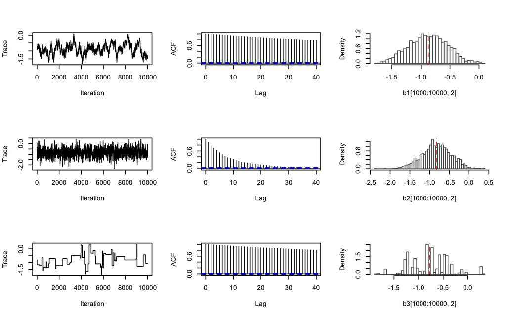

```r
b1 <- mh(1e4, .1,y,X)
b2 <- mh(1e4, 1,y,X)
b3 <- mh(1e4, 4,y,X)

par(mfcol=c(3,3))
##beta2
plot(b1[,2], type="l", ylab="Trace", xlab="Iteration")
plot(b2[,2], type="l", ylab="Trace", xlab="Iteration")
plot(b3[,2], type="l", ylab="Trace", xlab="Iteration")

acf(b1[,2], main="")
acf(b2[,2], main="")
acf(b3[,2], main="")

hist(b1[1e3:1e4,2], breaks=50, border="gray40",freq=F, main="")
abline(v=mean(b1[1e3:1e4,2]), col="firebrick3", lty=2)
hist(b2[1e3:1e4,2], breaks=50, border="gray40",freq=F, main="")
abline(v=mean(b2[1e3:1e4,2]), col="firebrick3", lty=2)
hist(b3[1e3:1e4,2], breaks=50, border="gray40",freq=F, main="")
abline(v=mean(b3[1e3:1e4,2]), col="firebrick3", lty=2)
```

- Using the selected simulations, give a Monte Carlo estimate of the posterior mean and variance of $\beta$ (burn-in=1000 and thin=10). Compare the posterior estimates with the ones obtained using the function $\texttt{glm}$.

```r
post_sample <- b2[seq(1e3,1e4,by=10),]
par(mfrow=c(2,2))
plot(post_sample[,2], type="l", ylab="Trace", xlab="Iteration")
acf(post_sample[,2], main="")
hist(post_sample[,2], breaks=50, border="gray40",freq=F, main="")
abline(v=mean(b2[1e3:1e4,2]), col="firebrick3", lty=2)

round(colMeans(post_sample),2)
```

```
## [1] -119.80   -0.82    1.06    1.13    1.15
```

```r
round(summary(glm(y~X,family=binomial(link="probit")))$coefficients[,1],2)
```

```
## (Intercept)     XLength       XLeft      XRight     XBottom
##     -113.11       -0.81        1.06        1.06        1.11
```

```r
round(apply(post_sample, 2, var),2)
```

```
## [1] 6922.55    0.14    0.37    0.30    0.03
```

```r
round(diag(summary(glm(y~X,family=binomial(link="probit")))$cov.unscaled),2)
```

```
## (Intercept)     XLength       XLeft      XRight     XBottom
##     6956.75        0.15        0.36        0.29        0.03
```

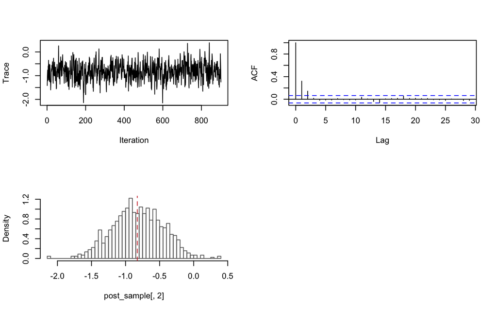

- The same model can be written using the definition of an auxiliary latent variable:
  $$\begin{align*}
  y_i &= \mathbb{1}_{z_i> 0}\\
  z_i &\sim N(x_i \beta,1)
  \end{align*}$$

  Prove that the two model specifications are equivalent.
- Prove or accept that the full conditional distributions for $z$ and $\beta$ are

  $$z_i| \beta, x_i, y_i \sim \begin{cases}
  N_+(x_i\beta,1) \quad \text{if } y_i=1\\
  N_-(x_i\beta,1) \quad \text{if } y_i=0
  \end{cases}$$
  where $N_+$ and $N_-$ represent the left and right truncated normal distribution on 0, and
  $$\beta|X,y,z \sim N_{q+1}((X^T X)^{-1}X^Tz, (X^TX)^{-1})$$
- Implement a Gibbs’ sampler to generate $\beta$ from the posterior distribution.
- Simulate a sample of 10000 draws of $\beta$ and plot the results.

```r
library(truncnorm)

gs <- function(Nsim,y,X){
    beta <- matrix(0,nrow=Nsim,ncol=ncol(X))
    z <- c()
    beta[1,]=summary(glm(y~X,family=binomial(link="probit")))$coefficients[,1]
    S <- solve(t(X)%*%X)
    SX <- S%*%t(X)
    for(i in 2:Nsim){
        mu <- X%*%beta[i-1,]
        z[y==1] <- rtruncnorm(sum(y),a=0,b=Inf,mean=mu[y==1],sd=1)
        z[y==0] <- rtruncnorm(n-sum(y),a=-Inf,b=0,mean=mu[y==0],sd=1)
        beta[i,] <- rmvnorm(1, SX%*%z,S)
    }
    return(beta)
}
```

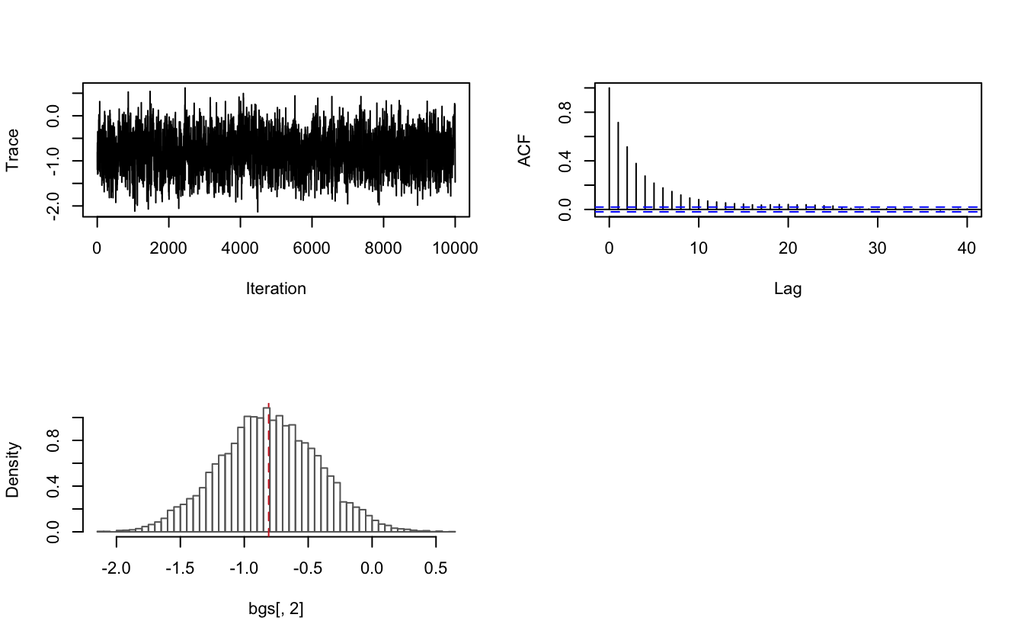

```r
bgs <- gs(1e4,y,X)
par(mfrow=c(2,2))
plot(bgs[,2], type="l", ylab="Trace", xlab="Iteration")
acf(bgs[,2], main="")
hist(bgs[,2], breaks=50, border="gray40",freq=F, main="")
abline(v=mean(bgs[1e3:1e4,2]), col="firebrick3", lty=2)
```

```r
post_sample <- bgs[seq(1e3,1e4,by=10),]
par(mfrow=c(2,2))
plot(post_sample[,2], type="l", ylab="Trace", xlab="Iteration")
acf(post_sample[,2], main="")
hist(post_sample[,2], breaks=50, border="gray40",freq=F, main="")
abline(v=mean(post_sample[,2]), col="firebrick3", lty=2)


round(colMeans(post_sample),2)
```

```
## [1] -121.98   -0.82    1.09    1.12    1.15
```

```r
round(summary(glm(y~X,family=binomial(link="probit")))$coefficients[,1],2)
```

```
## (Intercept)     XLength       XLeft      XRight     XBottom
##     -113.11       -0.81        1.06        1.06        1.11
```

```r
round(apply(post_sample, 2, var),2)
```

```
## [1] 7378.55    0.15    0.40    0.29    0.03
```

```r
round(diag(summary(glm(y~X,family=binomial(link="probit")))$cov.unscaled),2)
```

```
## (Intercept)     XLength       XLeft      XRight     XBottom
##     6956.75        0.15        0.36        0.29        0.03
```

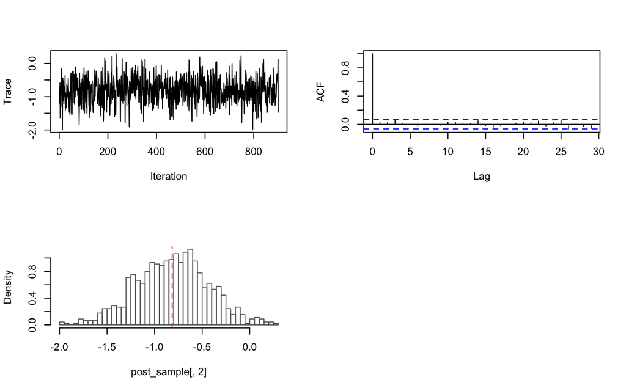